# Analysis Example: Intervention

Each of these pages provides an analysis run through for a different type of design. Each document is structured in the same way:

- First the data is introduced. For the purpose of these tutorials, I will only use examples where the data can be shared - either because it is from an open access publication, or because it is unpublished or simulated.
- Second, the structure of the data is discussed so that we can more easily see what data structure the design creates, and how this aligns to the variables in the data.
- Third, we translate the research questions into formal equations, and then `lmer()` code.
- Finally, we will follow those through for our example data.

# Overview

Intervention studies are where the researchers *intervenes* (e.g. through administration of a drug or treatment) as part of the study

The data used for this worked example are simulated to represent data from 50 participants, each measured at 3 different time-points (pre, during, and post) on a measure of stress. Half of the participants are in the control group, and half are in the treatment group (e.g. half received some cognitive behavioural therapy (CBT), half did not).

```r
set.seed(983)
library(tidyverse)
simMIX <- tibble(
  ppt = factor(rep(paste("ID", 1:50, sep=""),each=3)),
  ppt_int = rep(rnorm(50,0,15), each=3),
  stress = round(
    c(rnorm(75,c(50,45,42),sd=c(5, 6, 5)),
      rnorm(75,c(55,30,20),sd=c(6, 10, 5))) + ppt_int,
    0),
  time = factor(rep(c("Pre", "During", "Post"), each=1,50)),
  group = factor(c(rep("Control", 75), rep("Treatment", 75)))
)
```

# Data structure

Because we simulated our data, it is already nice and tidy. Each observation is a row, and we have variable indicating participant identifier (the `ppt` variable).

```r
bind_rows(head(simMIX[,-2]),tail(simMIX[,-2]))
```

```
## # A tibble: 12 × 4
##    ppt   stress time   group
##    <fct>  <dbl> <fct>  <fct>
##  1 ID1       65 Pre    Control
##  2 ID1       81 During Control
##  3 ID1       55 Post   Control
##  4 ID2       62 Pre    Control
##  5 ID2       57 During Control
##  6 ID2       67 Post   Control
##  7 ID49      58 Pre    Treatment
##  8 ID49      34 During Treatment
##  9 ID49      25 Post   Treatment
## 10 ID50      35 Pre    Treatment
## 11 ID50      21 During Treatment
## 12 ID50       0 Post   Treatment
```

# Equations

```r
library(lme4)
library(equatiomatic)
m2 <- lmer(stress ~ 1 + time + group +
             (1 | ppt), data = simMIX %>% mutate(across(c(time,group), factor)))
extract_eq(m2, mean_separate = T)
```

[output not shown]

# Analysis

```r
library(tidyverse)
library(lme4)
library(kableExtra)
```

## Describe

We now have two factors of interest, scores over `Time` and by `Group`. So we do our descriptive statistics by multiple grouping factors.

```r
sumMIX <-
  simMIX %>%
  group_by(time, group) %>%
  summarise(
    N = n_distinct(ppt),
    Mean = round(mean(stress, na.rm=T),2),
    SD = round(sd(stress, na.rm=T),2)
    )
```

```r
kable(sumMIX) %>%
  kable_styling("striped")
```

| time | group | N | Mean | SD |
| --- | --- | --- | --- | --- |
| During | Control | 25 | 49.64 | 13.23 |
| During | Treatment | 25 | 30.44 | 15.49 |
| Post | Control | 25 | 46.08 | 14.24 |
| Post | Treatment | 25 | 19.56 | 15.99 |
| Pre | Control | 25 | 52.84 | 14.60 |
| Pre | Treatment | 25 | 54.76 | 16.78 |

## Visualize Data

We can use a violin plot to visualise our data.

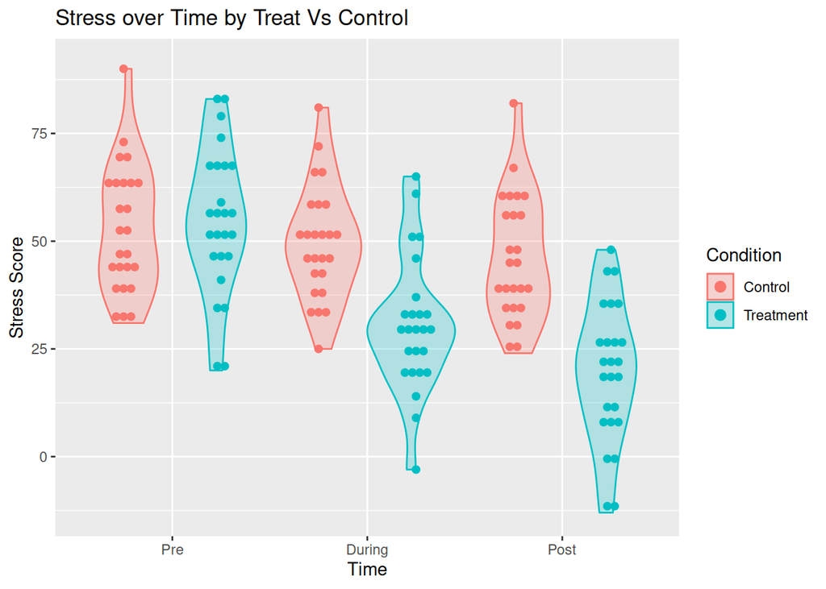

```r
simMIX %>%
  ggplot(aes(x=time, y=stress, color=group, fill=group))  +
  geom_violin(alpha = .25) +
  geom_dotplot(binaxis='y', stackdir='center', position=position_dodge(1),
               dotsize = 0.5) +
  scale_x_discrete(limits = c("Pre", "During", "Post")) +
  labs(x="Time", y = "Stress Score",
       title="Stress over Time by Treat Vs Control", color="Condition", fill="Condition")
```

It is useful to note that the violin plot contains much of the same information that a more traditional boxplot would have, but provides more information on the actual distribution with groups as it draws on density plots.

What we can see here is that over time, the control group shows little change, but the treatment group shows distinct declines.  
We can also consider line plots with separate facets for each condition:

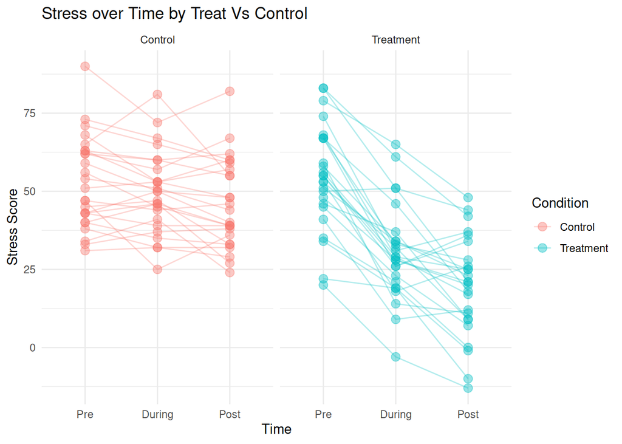

```r
simMIX %>%
  ggplot(aes(x=time, y=stress, group=ppt, col=group))  +
  geom_point(size=3, alpha=.4)+
  geom_line(alpha=.3)+
  facet_wrap(~group)+
  scale_x_discrete(limits = c("Pre", "During", "Post")) +
  labs(x="Time", y = "Stress Score",
       title="Stress over Time by Treat Vs Control", color="Condition", fill="Condition")+
  theme_minimal()
```

## Run models

Base model:

```r
m0 <- lmer(stress ~ 1 +
             (1 | ppt), data = simMIX)
summary(m0)
```

```
## Linear mixed model fit by REML ['lmerMod']
## Formula: stress ~ 1 + (1 | ppt)
##    Data: simMIX
##
## REML criterion at convergence: 1286.7
##
## Scaled residuals:
##      Min       1Q   Median       3Q      Max
## -2.02099 -0.49670  0.01511  0.49445  1.96548
##
## Random effects:
##  Groups   Name        Variance Std.Dev.
##  ppt      (Intercept) 179.7    13.40
##  Residual             209.7    14.48
## Number of obs: 150, groups:  ppt, 50
##
## Fixed effects:
##             Estimate Std. Error t value
## (Intercept)   42.220      2.234    18.9
```

Main effects:

```r
m1 <- lmer(stress ~ 1 + time + group +
             (1 | ppt), data = simMIX)
summary(m1)
```

```
## Linear mixed model fit by REML ['lmerMod']
## Formula: stress ~ 1 + time + group + (1 | ppt)
##    Data: simMIX
##
## REML criterion at convergence: 1185.9
##
## Scaled residuals:
##      Min       1Q   Median       3Q      Max
## -1.69666 -0.62649  0.01574  0.59245  1.92387
##
## Random effects:
##  Groups   Name        Variance Std.Dev.
##  ppt      (Intercept) 166.57   12.91
##  Residual              98.01    9.90
## Number of obs: 150, groups:  ppt, 50
##
## Fixed effects:
##                Estimate Std. Error t value
## (Intercept)      47.340      3.046  15.543
## timePost         -7.220      1.980  -3.646
## timePre          13.760      1.980   6.950
## groupTreatment  -14.600      3.992  -3.657
##
## Correlation of Fixed Effects:
##             (Intr) timPst timePr
## timePost    -0.325
## timePre     -0.325  0.500
## groupTrtmnt -0.655  0.000  0.000
```

Interaction:

```r
m2 <- lmer(stress ~ 1 + time + group + time*group +
             (1 | ppt), data = simMIX)
summary(m2)
```

```
## Linear mixed model fit by REML ['lmerMod']
## Formula: stress ~ 1 + time + group + time * group + (1 | ppt)
##    Data: simMIX
##
## REML criterion at convergence: 1096.5
##
## Scaled residuals:
##      Min       1Q   Median       3Q      Max
## -1.83946 -0.53326 -0.05639  0.53766  2.31546
##
## Random effects:
##  Groups   Name        Variance Std.Dev.
##  ppt      (Intercept) 184.82   13.595
##  Residual              43.26    6.577
## Number of obs: 150, groups:  ppt, 50
##
## Fixed effects:
##                         Estimate Std. Error t value
## (Intercept)               49.640      3.020  16.434
## timePost                  -3.560      1.860  -1.914
## timePre                    3.200      1.860   1.720
## groupTreatment           -19.200      4.272  -4.495
## timePost:groupTreatment   -7.320      2.631  -2.782
## timePre:groupTreatment    21.120      2.631   8.028
##
## Correlation of Fixed Effects:
##             (Intr) timPst timePr grpTrt tmPs:T
## timePost    -0.308
## timePre     -0.308  0.500
## groupTrtmnt -0.707  0.218  0.218
## tmPst:grpTr  0.218 -0.707 -0.354 -0.308
## tmPr:grpTrt  0.218 -0.354 -0.707 -0.308  0.500
```

For ease, lets compare all models with a likelihood ratio test:

```r
anova(m0,m1,m2)
```

```
## Data: simMIX
## Models:
## m0: stress ~ 1 + (1 | ppt)
## m1: stress ~ 1 + time + group + (1 | ppt)
## m2: stress ~ 1 + time + group + time * group + (1 | ppt)
##    npar    AIC    BIC  logLik deviance  Chisq Df Pr(>Chisq)
## m0    3 1296.1 1305.2 -645.07   1290.1
## m1    6 1211.8 1229.8 -599.89   1199.8 90.348  3  < 2.2e-16 ***
## m2    8 1131.9 1156.0 -557.97   1115.9 83.846  2  < 2.2e-16 ***
## ---
## Signif. codes:  0 '***' 0.001 '**' 0.01 '*' 0.05 '.' 0.1 ' ' 1
```

**Comparison with `aov()`**

As we did with the simple repeated measures, we can also compare the sums of squares breakdown for the LMM (`m2`) by calling `anova()` on the `lmer()` model.

First with `aov()`:

```r
m3 <- aov(stress ~ time + group + time*group +
            Error(ppt), data = simMIX)
summary(m3)
```

```
##
## Error: ppt
##           Df Sum Sq Mean Sq F value   Pr(>F)
## group      1   7993    7993   13.37 0.000633 ***
## Residuals 48  28691     598
## ---
## Signif. codes:  0 '***' 0.001 '**' 0.01 '*' 0.05 '.' 0.1 ' ' 1
##
## Error: Within
##            Df Sum Sq Mean Sq F value Pr(>F)
## time        2  11360    5680  131.31 <2e-16 ***
## time:group  2   5452    2726   63.01 <2e-16 ***
## Residuals  96   4153      43
## ---
## Signif. codes:  0 '***' 0.001 '**' 0.01 '*' 0.05 '.' 0.1 ' ' 1
```

And then summarise:

```r
anova(m2)
```

```
## Analysis of Variance Table
##            npar  Sum Sq Mean Sq F value
## time          2 11360.4  5680.2 131.305
## group         1   578.5   578.5  13.373
## time:group    2  5452.0  2726.0  63.014
```